# Etapa 2 — Análisis exploratorio de datos (EDA)

Tesis: análisis químico-sensorial de la calidad del whisky chileno

Alexandra Navarro

11-07-2026

# 1 Objetivo y marco metodológico

Este reporte documenta la **etapa de análisis exploratorio (EDA)**, aplicada sobre la matriz pura (`A_pura`, 34 filas) y sus componentes química y sensorial por separado. Se usó el marco clásico de 5 etapas de EDA (descriptivo, tipos de variable, datos ausentes, valores atípicos, correlación), complementado con técnicas específicas para **small data**:

- **Test de Dixon (Dixon, 1950, 1951; Rorabacher, 1991)**: detección de valores atípicos univariados apropiada para muestras pequeñas, donde tests basados en asintóticas (como Grubbs con n grande) son menos confiables.
- **T² de Hotelling y Q-residuals (Jackson & Mudholkar, 1979)**: detección de atípicos multivariados sobre los scores de componentes principales, considerando tanto la distancia dentro del subespacio PCA (T²) como fuera de él (Q).
- **ICC(1) de efectos aleatorios de una vía**: concordancia entre catadores dentro de la categoría de catador, implementado directamente (sin paquete externo) para transparencia del cálculo.
- **PCA/biplot por bloque analítico** (GC-FID, GC-MS, JU, Folin; y por sesión de cata en el lado sensorial), evitando mezclar bloques que no se solapan completamente.

Este reporte se regenera automáticamente si se vuelven a correr los scripts de `scripts/R/exploratorio/`, ya que enumera dinámicamente las figuras existentes en `outputs/exploratorio/`.

# 2 Análisis exploratorio químico

| indicador | valor |
| --- | --- |
| Unidad de analisis quimica | Unidad analitica quimica |
| Unidades analiticas quimicas totales | 115 |
| Unidades con cata confirmada | 52 |
| Unidades sin cata confirmada | 63 |
| Bloques quimicos | 8 |
| Grupos quimicos (tecnica analitica) | 4 |
| Variables quimicas detectadas | 34 |
| Uso de este analisis | Analisis exploratorio de datos (EDA) no supervisado. No usa targets sensoriales. |

## 2.1 Completitud de datos por bloque

** 02_mapa_completitud **

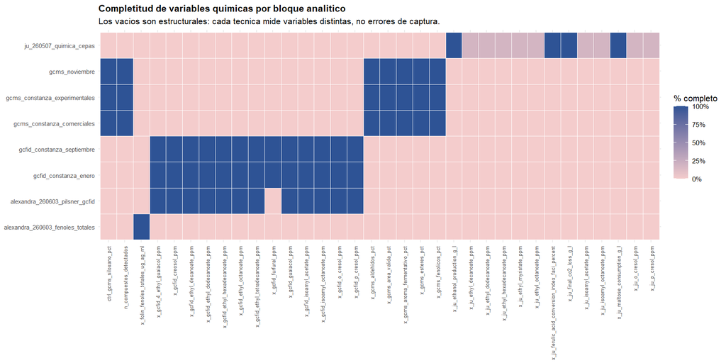

## 2.2 Distribuciones (histogramas y boxplots) por bloque

** 01_histogramas_Fenoles_totales **

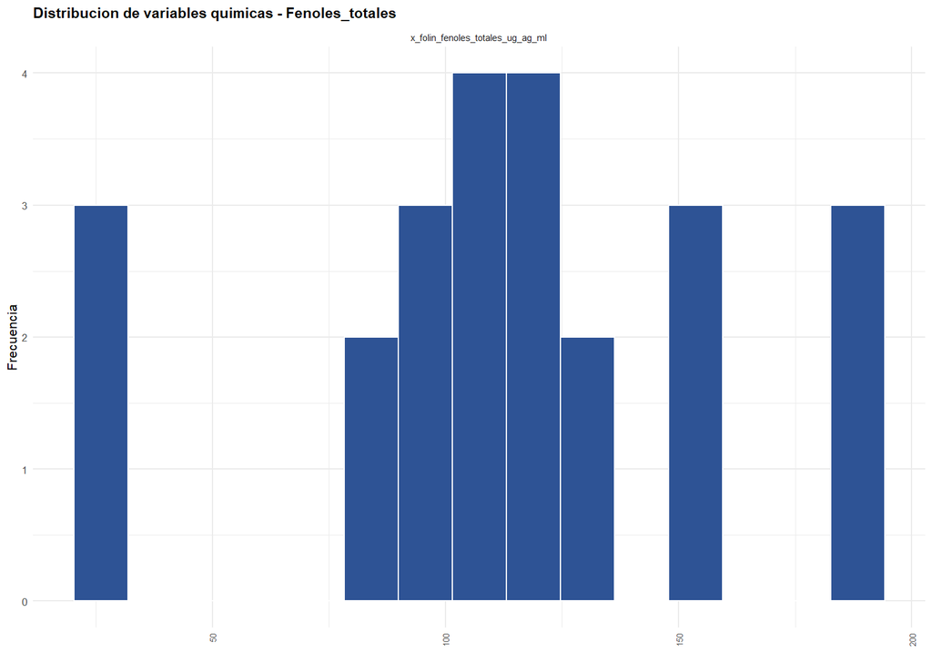

** 01_histogramas_GCFID **

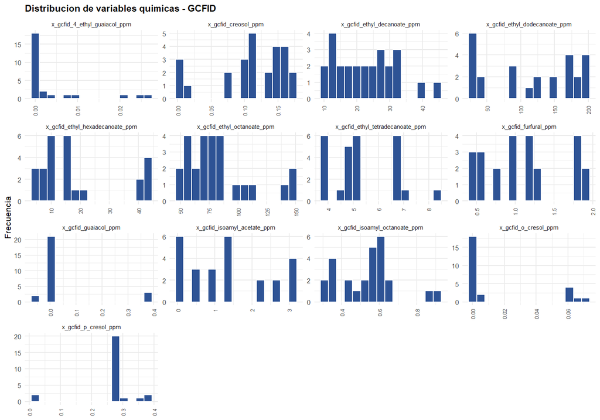

** 01_histogramas_GCMS **

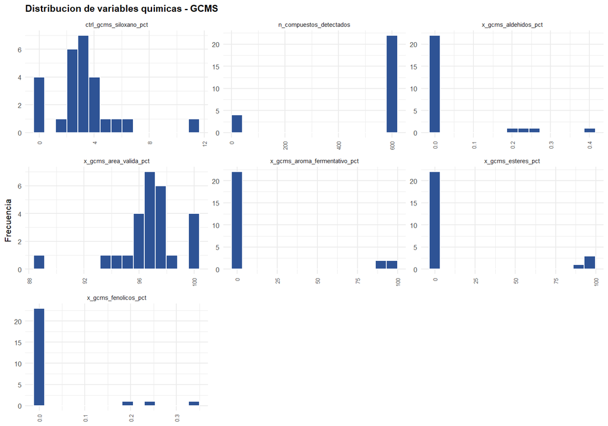

** 01_histogramas_JU **

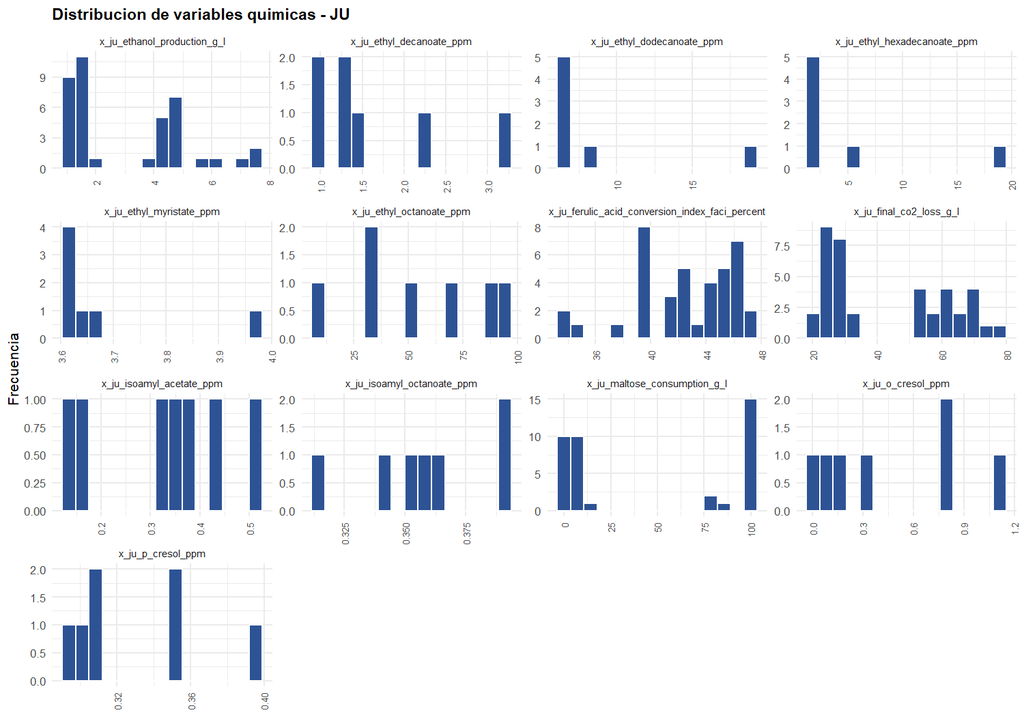

** 03_boxplots_Fenoles_totales **

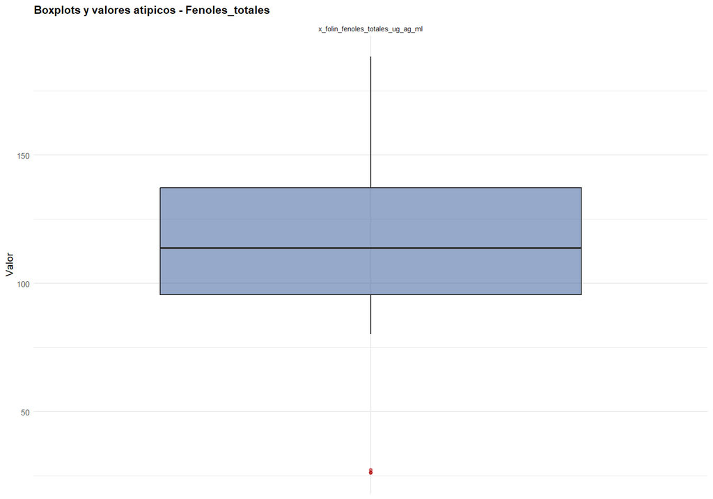

** 03_boxplots_GCFID **

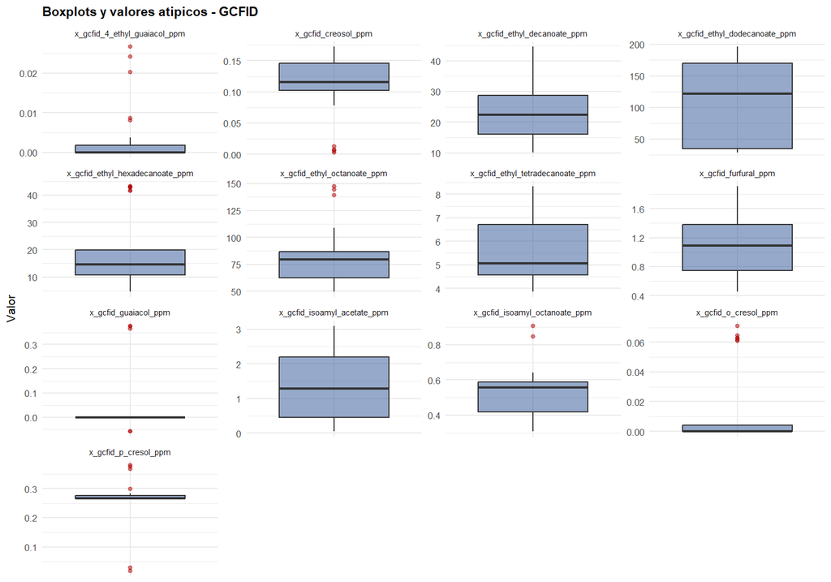

** 03_boxplots_GCMS **

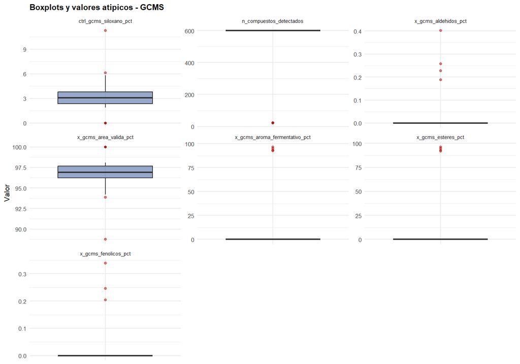

** 03_boxplots_JU **

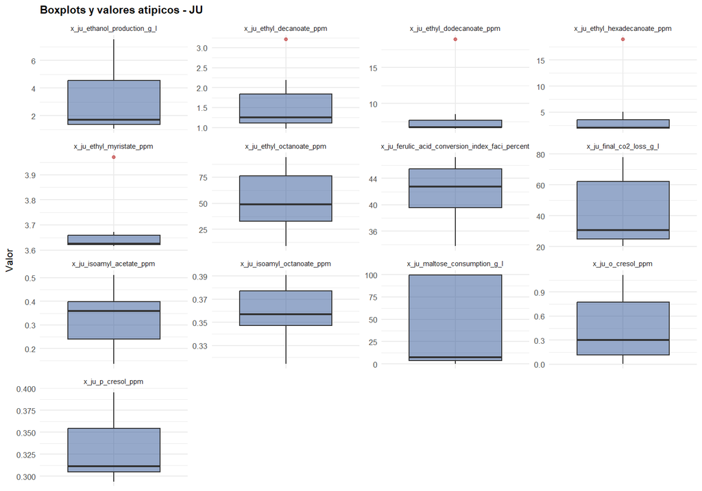

## 2.3 Valores atípicos: resumen clásico + test de Dixon

| variable_quimica | n_outliers |
| --- | --- |
| ctrl_gcms_siloxano_pct | 6 |
| x_gcfid_ethyl_hexadecanoate_ppm | 6 |
| x_gcfid_o_cresol_ppm | 6 |
| x_gcfid_p_cresol_ppm | 6 |
| x_gcms_area_valida_pct | 6 |
| x_gcfid_4_ethyl_guaiacol_ppm | 5 |
| x_gcfid_guaiacol_ppm | 5 |
| n_compuestos_detectados | 4 |
| x_gcfid_creosol_ppm | 4 |
| x_gcms_aldehidos_pct | 4 |
| x_gcms_aroma_fermentativo_pct | 4 |
| x_gcms_esteres_pct | 4 |
| x_folin_fenoles_totales_ug_ag_ml | 3 |
| x_gcfid_ethyl_octanoate_ppm | 3 |
| x_gcms_fenolicos_pct | 3 |
| x_gcfid_isoamyl_octanoate_ppm | 2 |
| x_ju_ethyl_decanoate_ppm | 1 |
| x_ju_ethyl_dodecanoate_ppm | 1 |
| x_ju_ethyl_hexadecanoate_ppm | 1 |
| x_ju_ethyl_myristate_ppm | 1 |

| es_outlier_dixon | n_variables |
| --- | --- |
| sin_outlier | 17 |
| outlier_detectado | 13 |

## 2.4 Correlación entre variables químicas

** 04_correlacion_GCFID **

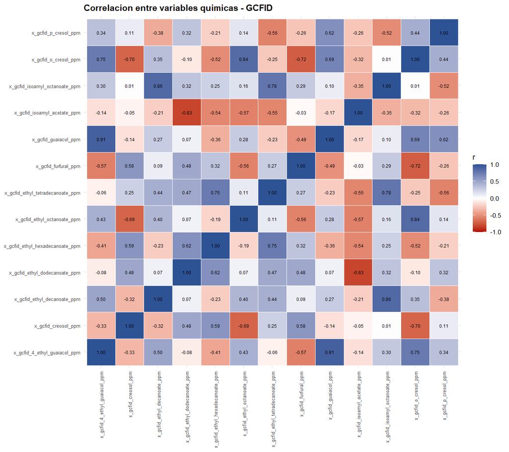

** 04_correlacion_GCMS **

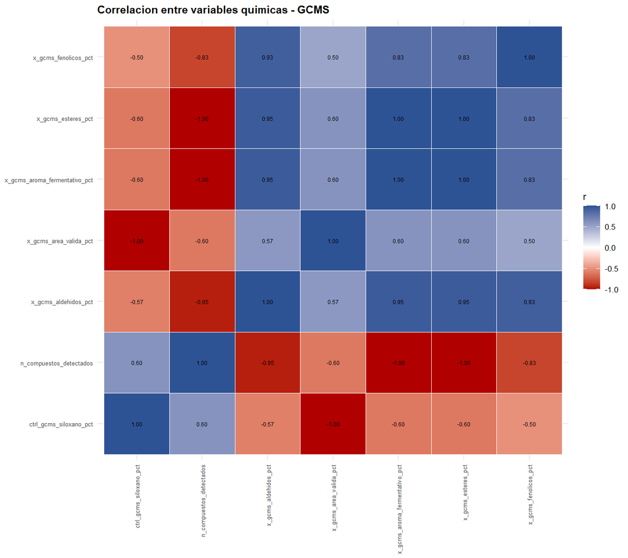

** 04_correlacion_JU **

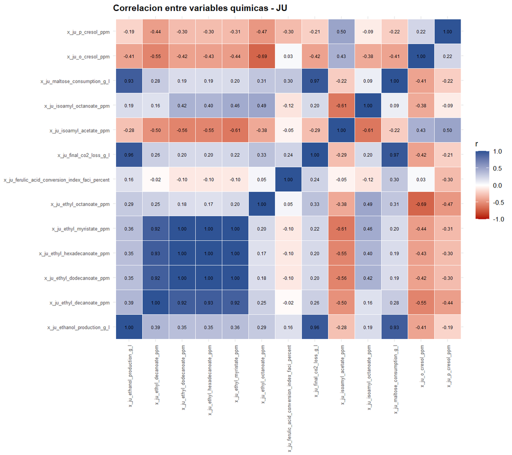

## 2.5 Componentes principales (PCA/biplot) y atípicos multivariados (T²/Q-residual)

| grupo_pca | estado | n_filas | n_variables | pc1_varianza | pc2_varianza | pc1_pc2_varianza | motivo | t2_n_comp | t2_limite | q_limite |
| --- | --- | --- | --- | --- | --- | --- | --- | --- | --- | --- |
| Fenoles_totales | no_calculado | 24 | 1 | NA | NA | NA | Se requieren al menos 3 filas y 2 variables con variabilidad. | NA | NA | NA |
| GCFID | calculado | 26 | 13 | 0.3632469 | 0.2744804 | 0.6377273 | NA | 2 | 7.089221 | 12.736922 |
| GCMS | calculado | 26 | 7 | 0.8036152 | 0.1549709 | 0.9585860 | NA | 2 | 7.089221 | 1.031612 |
| JU | calculado | 39 | 13 | 0.4468083 | 0.1983791 | 0.6451874 | NA | 2 | 6.679627 | 10.798231 |

** 05_biplot_pca_GCFID **

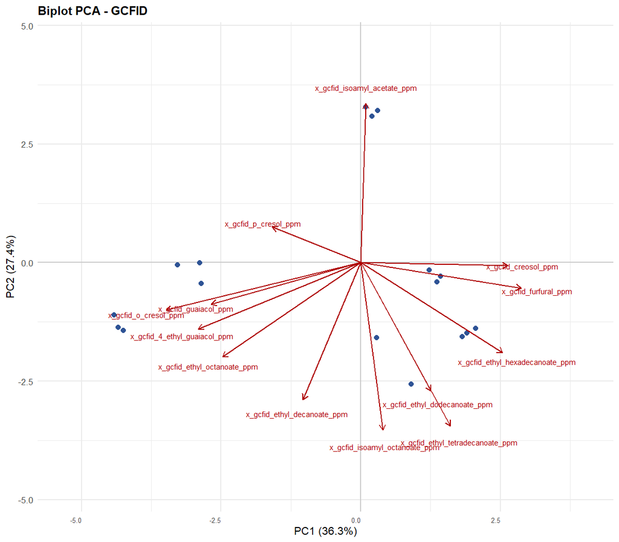

** 05_biplot_pca_GCMS **

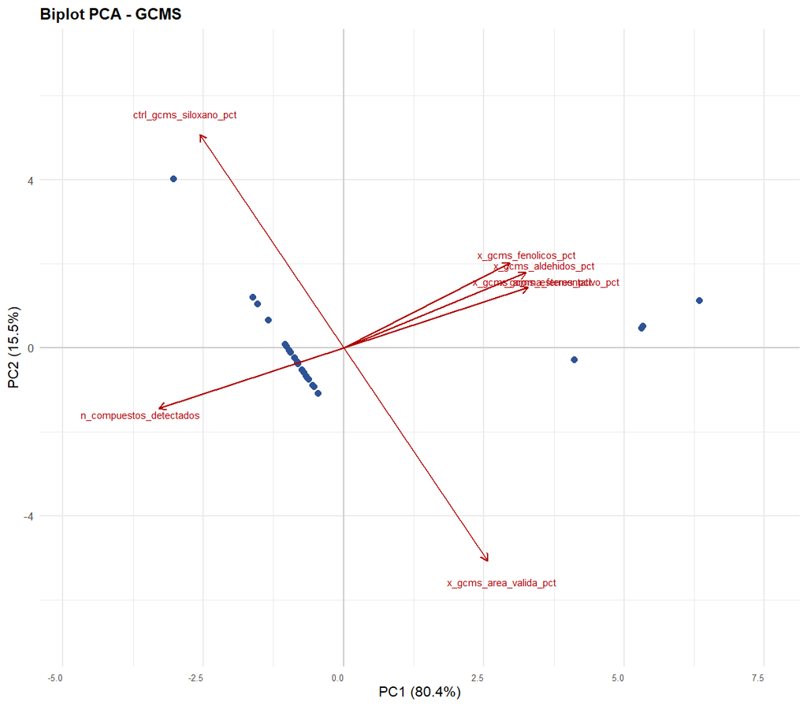

** 05_biplot_pca_JU **

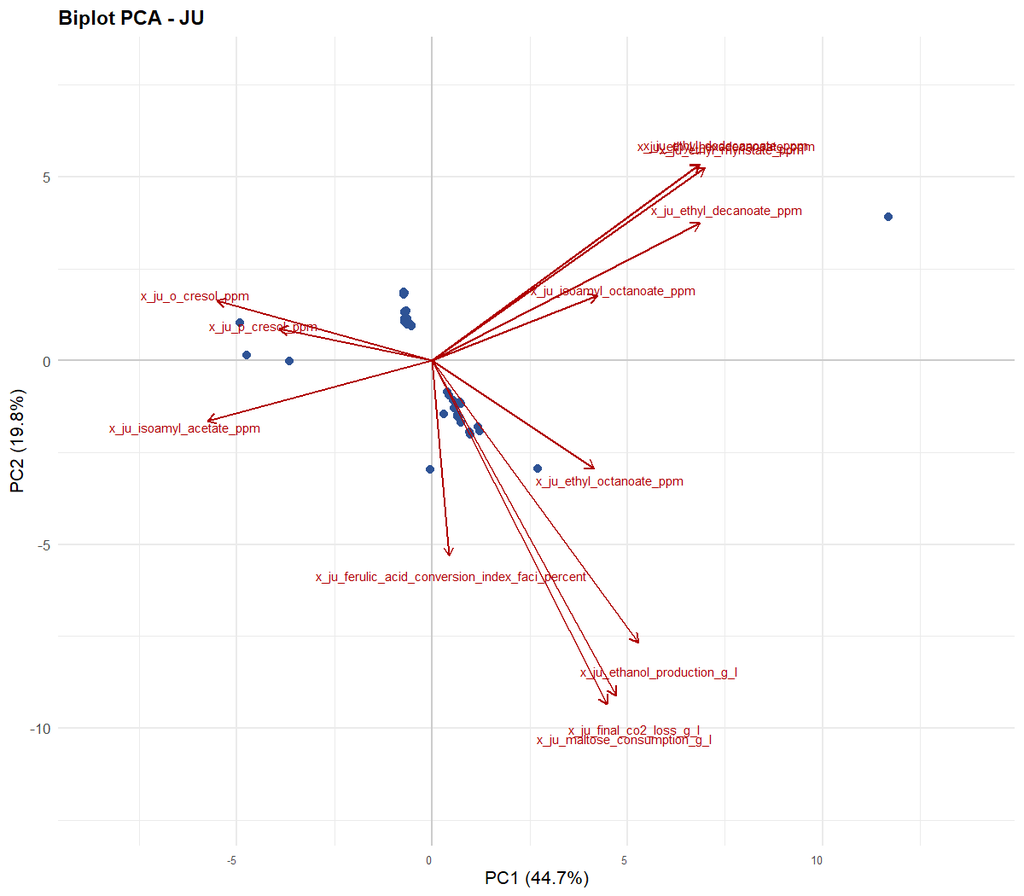

** 06_distancia_t2_q_GCFID **

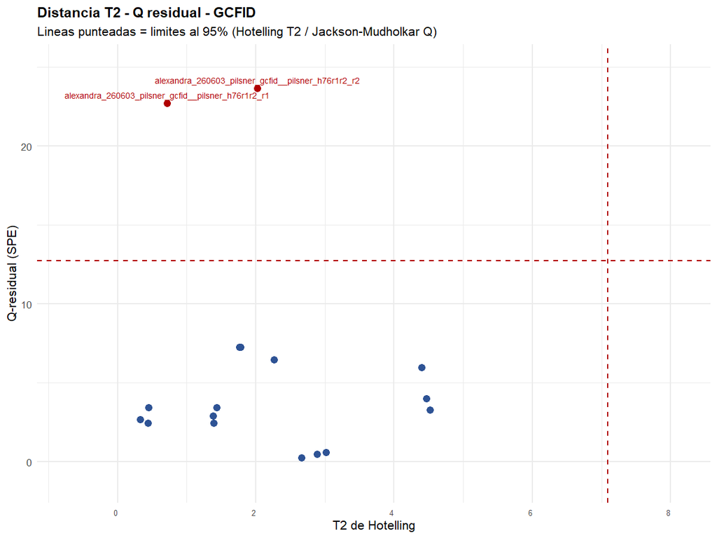

** 06_distancia_t2_q_GCMS **

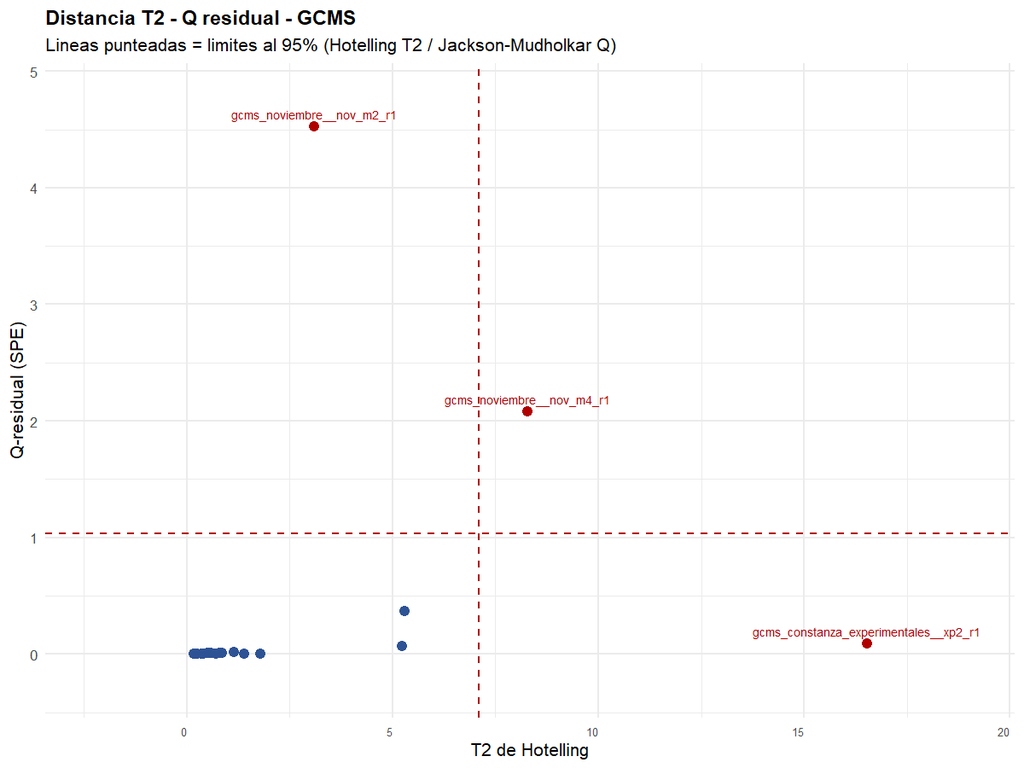

** 06_distancia_t2_q_JU **

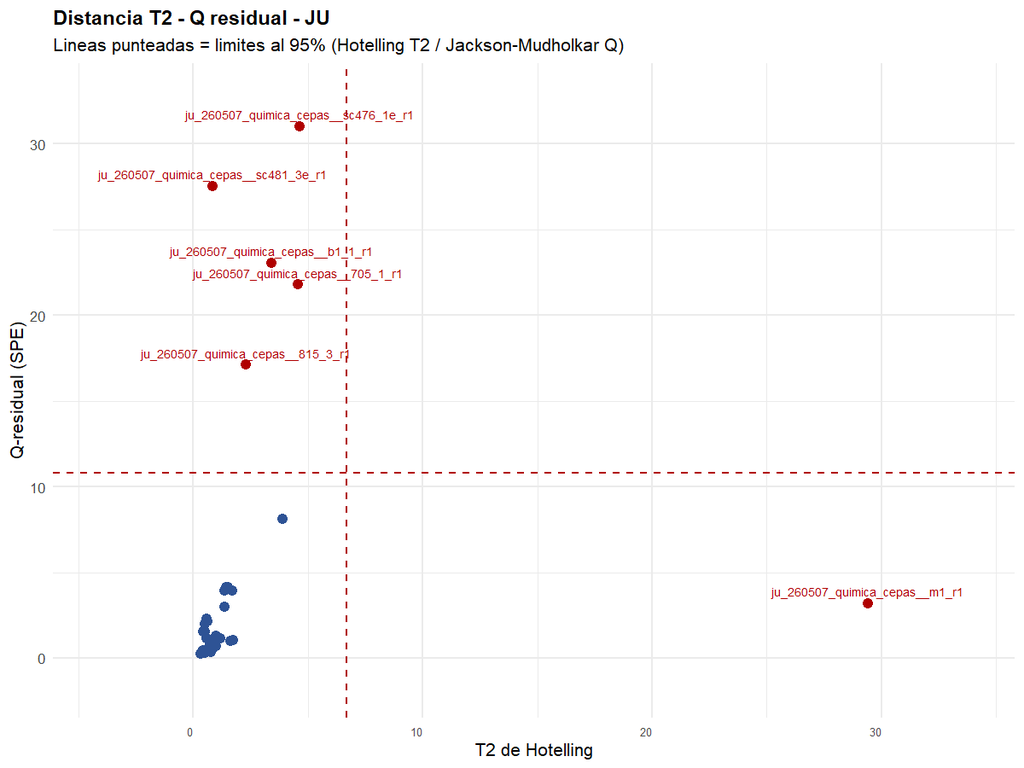

| grupo_pca | unidad_analitica_id | bloque_id | muestra_base | t2_hotelling | excede_t2 | q_residual | excede_q |
| --- | --- | --- | --- | --- | --- | --- | --- |
| GCFID | alexandra_260603_pilsner_gcfid__pilsner_h76r1r2_r2 | alexandra_260603_pilsner_gcfid | Pilsner_H76R1R2 | 2.0242056 | FALSE | 23.6476336 | TRUE |
| GCFID | alexandra_260603_pilsner_gcfid__pilsner_h76r1r2_r1 | alexandra_260603_pilsner_gcfid | Pilsner_H76R1R2 | 0.7192313 | FALSE | 22.6862686 | TRUE |
| GCMS | gcms_constanza_experimentales__xp2_r1 | gcms_constanza_experimentales | XP2 | 16.5217126 | TRUE | 0.0902967 | FALSE |
| GCMS | gcms_noviembre__nov_m4_r1 | gcms_noviembre | NOV_M4 | 8.2854246 | TRUE | 2.0849687 | TRUE |
| GCMS | gcms_noviembre__nov_m2_r1 | gcms_noviembre | NOV_M2 | 3.0953404 | FALSE | 4.5268455 | TRUE |
| JU | ju_260507_quimica_cepas__m1_r1 | ju_260507_quimica_cepas | M1 | 29.4083893 | TRUE | 3.1839252 | FALSE |
| JU | ju_260507_quimica_cepas__sc476_1e_r1 | ju_260507_quimica_cepas | SC476_1e | 4.6504401 | FALSE | 31.0281080 | TRUE |
| JU | ju_260507_quimica_cepas__705_1_r1 | ju_260507_quimica_cepas | 705.1 | 4.5737151 | FALSE | 21.7831575 | TRUE |
| JU | ju_260507_quimica_cepas__b1_1_r1 | ju_260507_quimica_cepas | B1.1 | 3.4151925 | FALSE | 23.0565893 | TRUE |
| JU | ju_260507_quimica_cepas__815_3_r1 | ju_260507_quimica_cepas | 815.3 | 2.2894972 | FALSE | 17.1075559 | TRUE |
| JU | ju_260507_quimica_cepas__sc481_3e_r1 | ju_260507_quimica_cepas | SC481_3e | 0.8398602 | FALSE | 27.5250230 | TRUE |

# 3 Análisis exploratorio sensorial

| indicador | valor |
| --- | --- |
| Unidad individual sensorial | Evaluacion individual de catador |
| Muestras sensoriales totales | 23 |
| Evaluaciones individuales totales | 263 |
| Evaluaciones con quimica confirmada | 226 |
| Evaluaciones sin quimica confirmada | 37 |
| Bloques sensoriales | 5 |
| Targets sensoriales detectados | 34 |
| Muestras sensoriales agregadas | 23 |
| Uso de este analisis | Analisis exploratorio de datos (EDA), no usa predictores quimicos. |
| Advertencia metodologica | Las evaluaciones individuales son reales, pero no equivalen a muestras quimicas independientes. |

## 3.1 Completitud y distribuciones de los targets sensoriales

** 02_mapa_completitud **

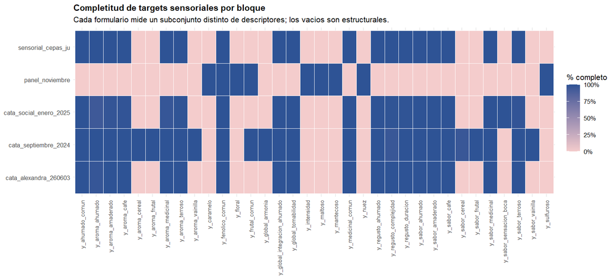

** 01_histogramas_targets **

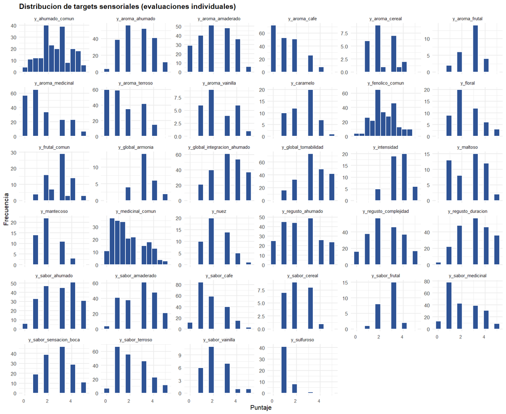

## 3.2 Distribuciones por sesión de cata

** 03_boxplots_targets_por_bloque **

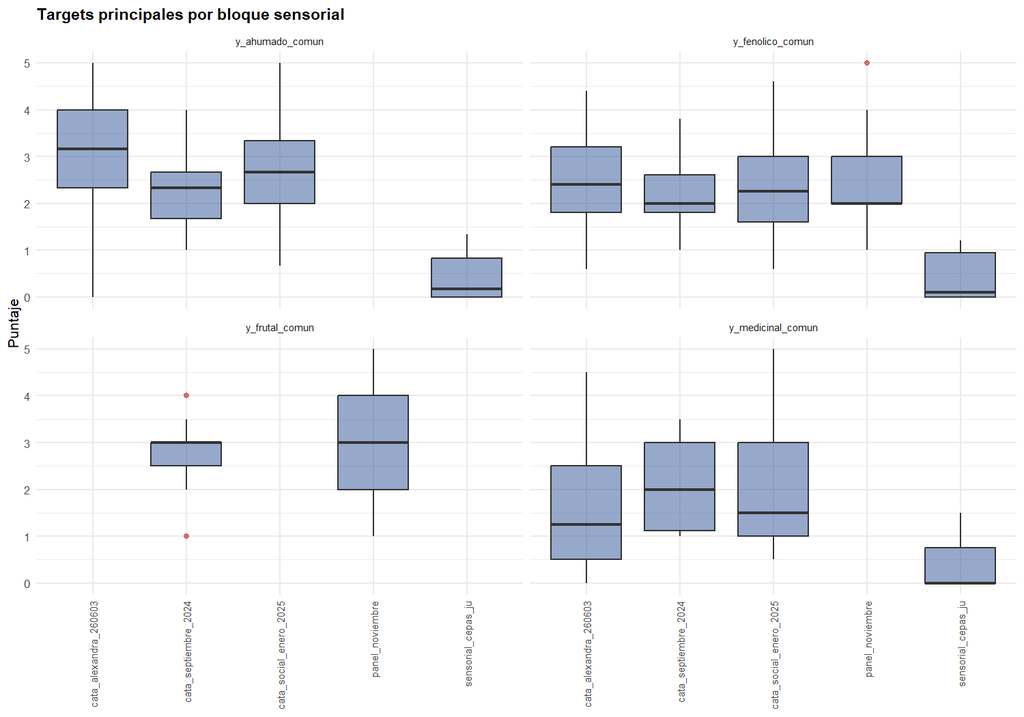

## 3.3 Correlación entre targets sensoriales

** 05_correlacion_targets **

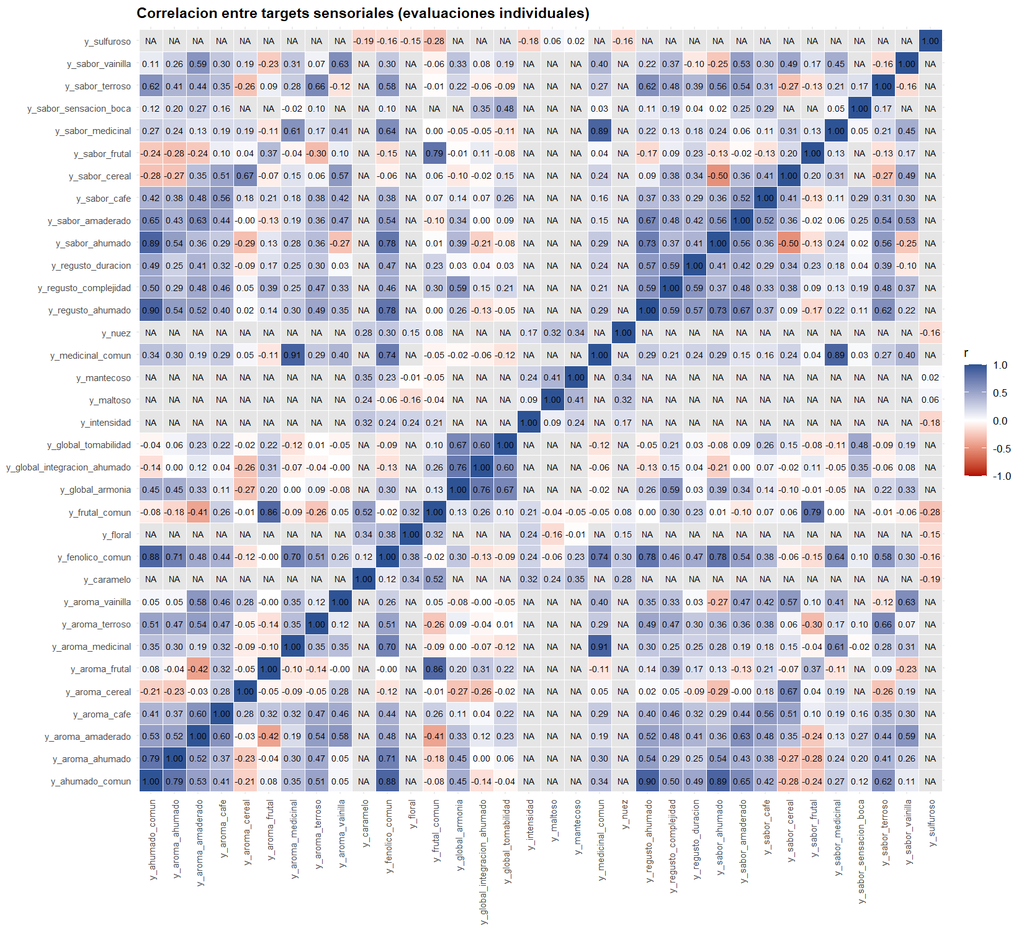

## 3.4 Categoría de catador: perfil y concordancia (ICC)

Esta sección usa el campo “categoría de catador” (experto/semi-experto/consumidor, según corresponda), extraído del cuestionario original y antes no utilizado en el análisis.

| grupo_sensorial | bloque_sensorial | muestra_cata | identificador_sensorial | categoria_catador | target | n_evaluaciones | media | desviacion_estandar |
| --- | --- | --- | --- | --- | --- | --- | --- | --- |
| historico_enero | cata_social_enero_2025 | Muestra 1 | C70 | Aficionado al whisky | y_ahumado_comun | 7 | 2.1904762 | 1.0157490 |
| historico_enero | cata_social_enero_2025 | Muestra 1 | C70 | Consumidor General de Destilados | y_ahumado_comun | 20 | 2.0666667 | 0.8207827 |
| historico_enero | cata_social_enero_2025 | Muestra 1 | C70 | Experto/ Sommelier | y_ahumado_comun | 4 | 0.9166667 | 0.3191424 |
| historico_enero | cata_social_enero_2025 | Muestra 1 | C70 | Aficionado al whisky | y_aroma_ahumado | 7 | 2.2857143 | 0.9511897 |
| historico_enero | cata_social_enero_2025 | Muestra 1 | C70 | Consumidor General de Destilados | y_aroma_ahumado | 20 | 2.5000000 | 1.1002392 |
| historico_enero | cata_social_enero_2025 | Muestra 1 | C70 | Experto/ Sommelier | y_aroma_ahumado | 4 | 1.0000000 | 0.0000000 |
| historico_enero | cata_social_enero_2025 | Muestra 1 | C70 | Aficionado al whisky | y_aroma_amaderado | 7 | 1.7142857 | 1.4960265 |
| historico_enero | cata_social_enero_2025 | Muestra 1 | C70 | Consumidor General de Destilados | y_aroma_amaderado | 19 | 1.7894737 | 0.9763280 |
| historico_enero | cata_social_enero_2025 | Muestra 1 | C70 | Experto/ Sommelier | y_aroma_amaderado | 4 | 1.0000000 | 1.4142136 |
| historico_enero | cata_social_enero_2025 | Muestra 1 | C70 | Aficionado al whisky | y_aroma_cafe | 7 | 1.1428571 | 1.0690450 |
| historico_enero | cata_social_enero_2025 | Muestra 1 | C70 | Consumidor General de Destilados | y_aroma_cafe | 20 | 0.9500000 | 0.9445132 |
| historico_enero | cata_social_enero_2025 | Muestra 1 | C70 | Experto/ Sommelier | y_aroma_cafe | 4 | 0.2500000 | 0.5000000 |
| historico_enero | cata_social_enero_2025 | Muestra 1 | C70 | Aficionado al whisky | y_aroma_medicinal | 6 | 0.5000000 | 0.5477226 |
| historico_enero | cata_social_enero_2025 | Muestra 1 | C70 | Consumidor General de Destilados | y_aroma_medicinal | 20 | 1.3500000 | 1.2258187 |
| historico_enero | cata_social_enero_2025 | Muestra 1 | C70 | Experto/ Sommelier | y_aroma_medicinal | 4 | 1.2500000 | 1.2583057 |
| historico_enero | cata_social_enero_2025 | Muestra 1 | C70 | Aficionado al whisky | y_aroma_terroso | 6 | 0.8333333 | 1.1690452 |
| historico_enero | cata_social_enero_2025 | Muestra 1 | C70 | Consumidor General de Destilados | y_aroma_terroso | 20 | 1.3500000 | 1.3088766 |
| historico_enero | cata_social_enero_2025 | Muestra 1 | C70 | Experto/ Sommelier | y_aroma_terroso | 4 | 0.0000000 | 0.0000000 |
| historico_enero | cata_social_enero_2025 | Muestra 1 | C70 | Aficionado al whisky | y_fenolico_comun | 7 | 1.8071429 | 0.9038937 |
| historico_enero | cata_social_enero_2025 | Muestra 1 | C70 | Consumidor General de Destilados | y_fenolico_comun | 20 | 2.0000000 | 0.5191085 |
| historico_enero | cata_social_enero_2025 | Muestra 1 | C70 | Experto/ Sommelier | y_fenolico_comun | 4 | 1.1000000 | 0.4163332 |
| historico_enero | cata_social_enero_2025 | Muestra 1 | C70 | Aficionado al whisky | y_global_integracion_ahumado | 7 | 3.7142857 | 1.3801311 |
| historico_enero | cata_social_enero_2025 | Muestra 1 | C70 | Consumidor General de Destilados | y_global_integracion_ahumado | 20 | 3.4000000 | 1.1876558 |
| historico_enero | cata_social_enero_2025 | Muestra 1 | C70 | Experto/ Sommelier | y_global_integracion_ahumado | 4 | 4.2500000 | 0.9574271 |
| historico_enero | cata_social_enero_2025 | Muestra 1 | C70 | Aficionado al whisky | y_global_tomabilidad | 7 | 3.7142857 | 1.4960265 |
| historico_enero | cata_social_enero_2025 | Muestra 1 | C70 | Consumidor General de Destilados | y_global_tomabilidad | 20 | 3.0500000 | 0.9986833 |
| historico_enero | cata_social_enero_2025 | Muestra 1 | C70 | Experto/ Sommelier | y_global_tomabilidad | 4 | 3.2500000 | 0.5000000 |
| historico_enero | cata_social_enero_2025 | Muestra 1 | C70 | Aficionado al whisky | y_medicinal_comun | 7 | 1.2142857 | 0.9063270 |
| historico_enero | cata_social_enero_2025 | Muestra 1 | C70 | Consumidor General de Destilados | y_medicinal_comun | 20 | 1.9000000 | 0.9262261 |
| historico_enero | cata_social_enero_2025 | Muestra 1 | C70 | Experto/ Sommelier | y_medicinal_comun | 4 | 1.3750000 | 0.7500000 |

[output cut: 255 more lines]

| categoria_catador | target | icc1 | n_muestras | n_observaciones | interpretacion |
| --- | --- | --- | --- | --- | --- |
| Experto/ Sommelier | y_ahumado_comun | 0.6000569 | 5 | 17 | concordancia buena |
| Aficionado al whisky | y_ahumado_comun | 0.3750204 | 5 | 35 | concordancia moderada |
| Consumidor General de Destilados | y_ahumado_comun | 0.2608232 | 5 | 93 | concordancia moderada |
| Experto/ Sommelier | y_fenolico_comun | 0.7505654 | 5 | 17 | concordancia excelente |
| Aficionado al whisky | y_fenolico_comun | 0.3427705 | 5 | 35 | concordancia moderada |
| Consumidor General de Destilados | y_fenolico_comun | 0.2929327 | 5 | 93 | concordancia moderada |
| Experto/ Sommelier | y_medicinal_comun | 0.4543738 | 5 | 17 | concordancia moderada |
| Aficionado al whisky | y_medicinal_comun | 0.1442246 | 5 | 35 | concordancia baja |
| Consumidor General de Destilados | y_medicinal_comun | 0.0993593 | 5 | 93 | concordancia baja |

** 06_boxplot_categoria_catador **

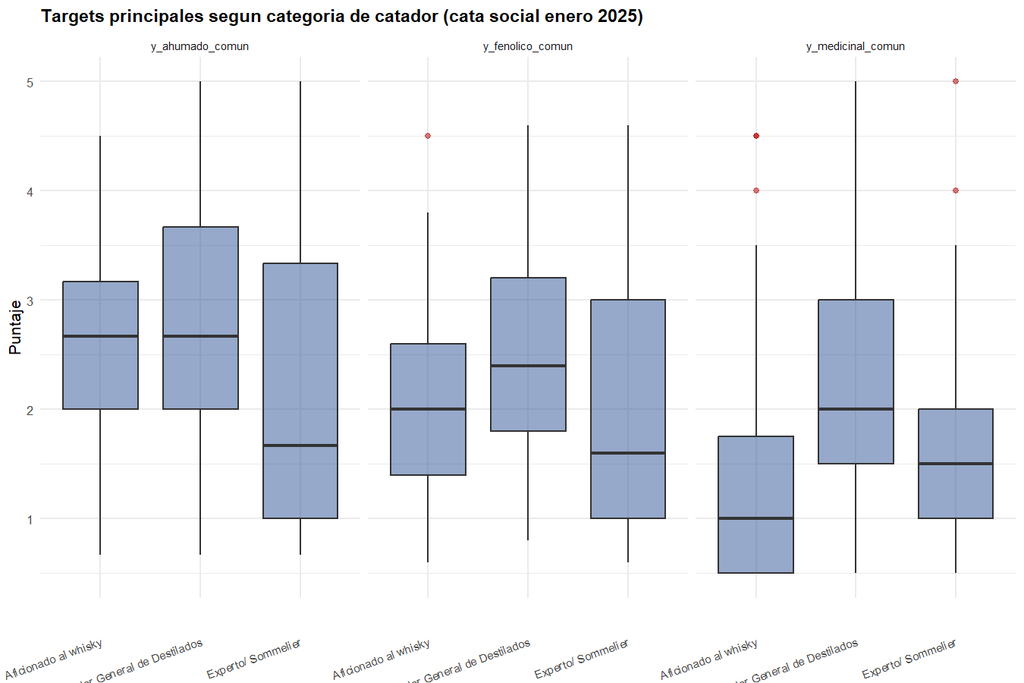

## 3.5 Perfiles sensoriales (radar) por muestra — ejemplos

Se generó un gráfico de radar por muestra y por dimensión sensorial (aroma, sabor, regusto final), automatizando lo que antes se armaba manualmente en Excel. Se muestran ejemplos representativos; el set completo está en `outputs/exploratorio/sensorial/` (archivos `07_radar_*` y `08_radar_categoria_*`).

** 07_radar_muestras_cata_alexandra_260603_aroma **

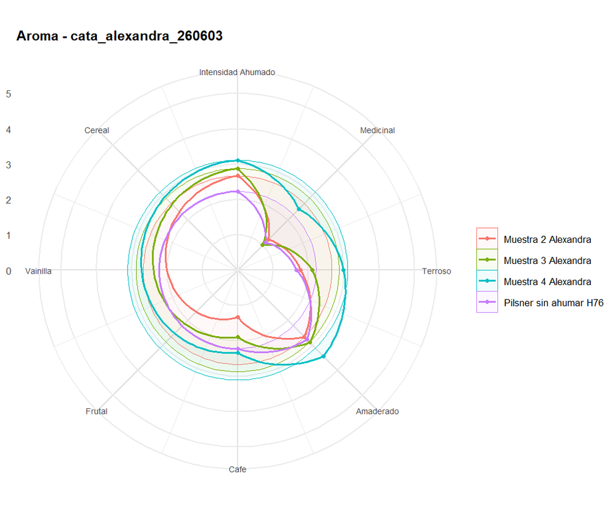

** 07_radar_muestras_cata_alexandra_260603_regusto_final **

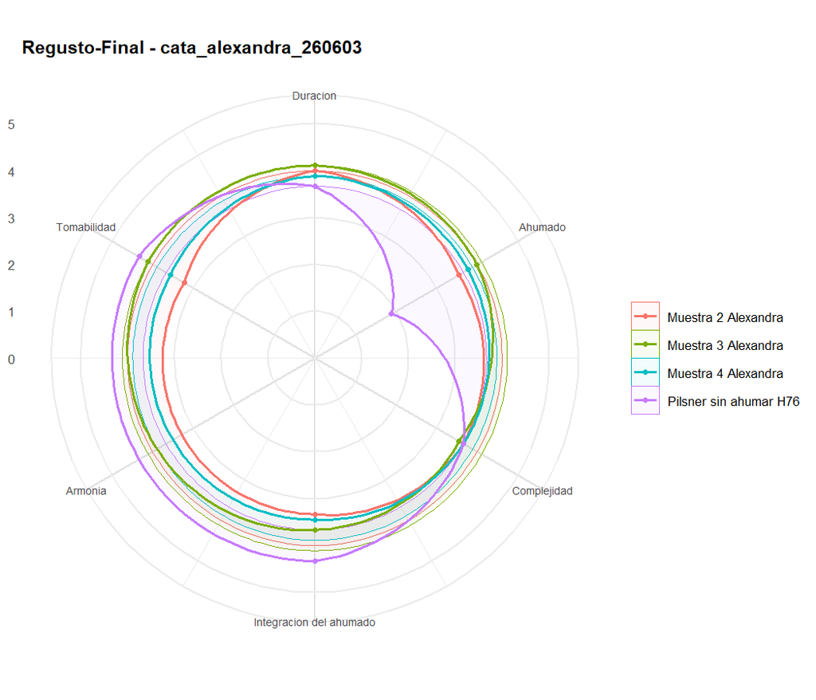

** 07_radar_muestras_cata_alexandra_260603_sabor **

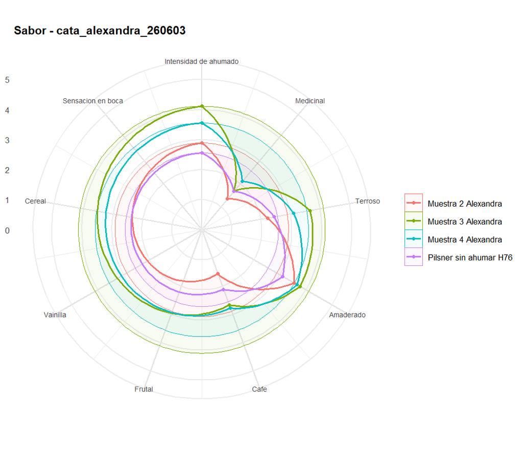

** 07_radar_muestras_cata_septiembre_2024_aroma **

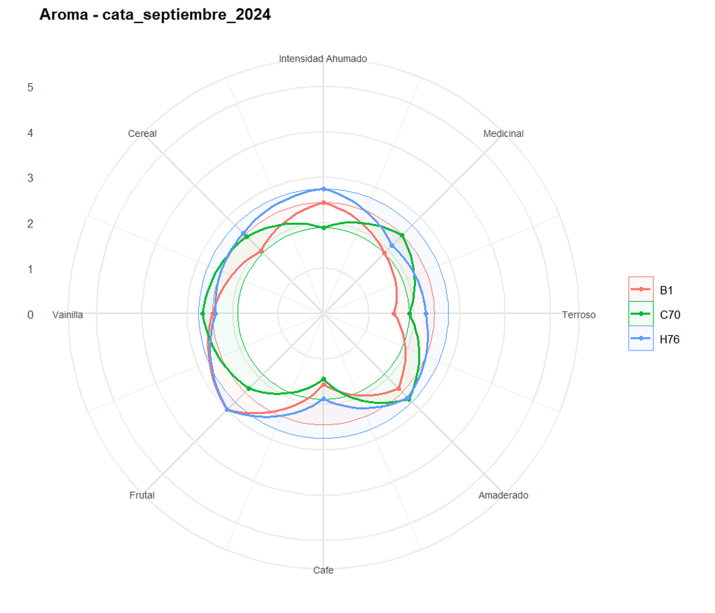

** 07_radar_muestras_cata_septiembre_2024_regusto_final **

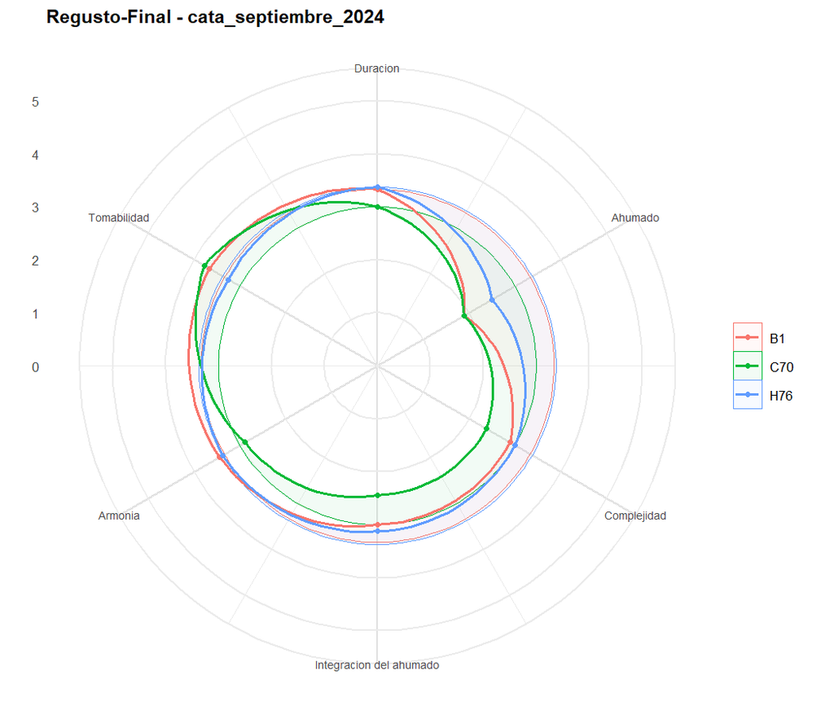

** 07_radar_muestras_cata_septiembre_2024_sabor **

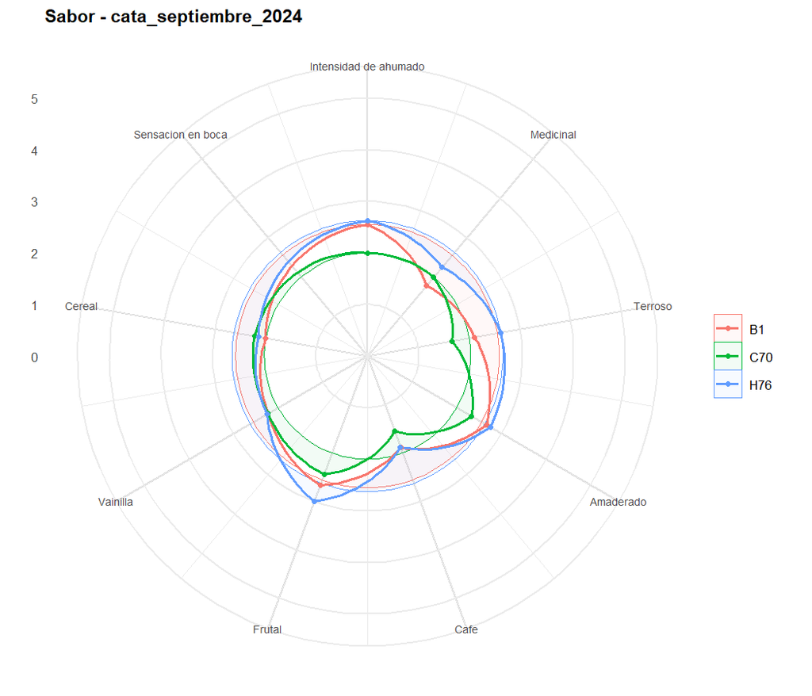